# 2021 INTRO Survey Report (Brief)

Abhik Roy

Released Febuary 1, 2022

[figure not shown]

## About

### Author

This report was prepared by [Dr. Abhik Roy](https://iam.asocialdatascientist.com/).

### Materials

The following materials are available.

Anonymized Data Set

Survey Skeleton

All Visualizations

## Study Overview

### Session Quality

Participant views on the degree of excellence of each session is given below.

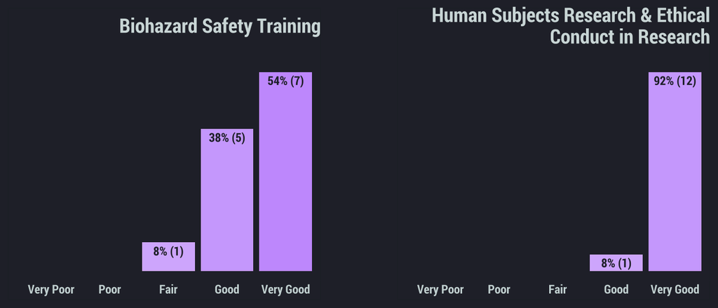

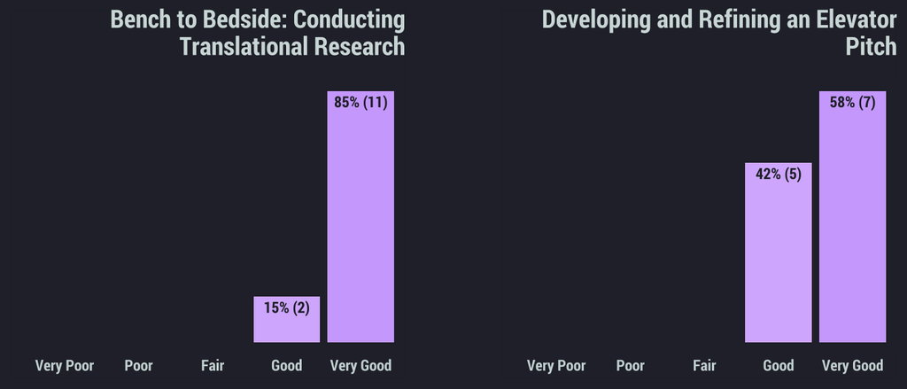

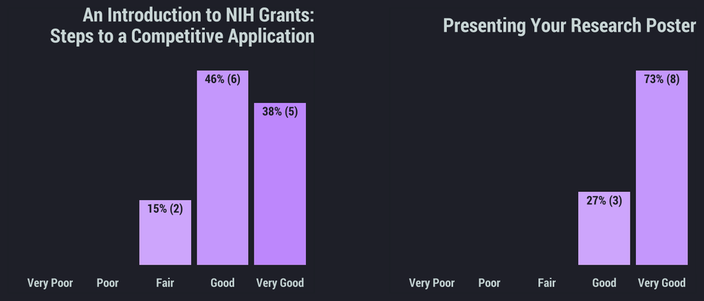

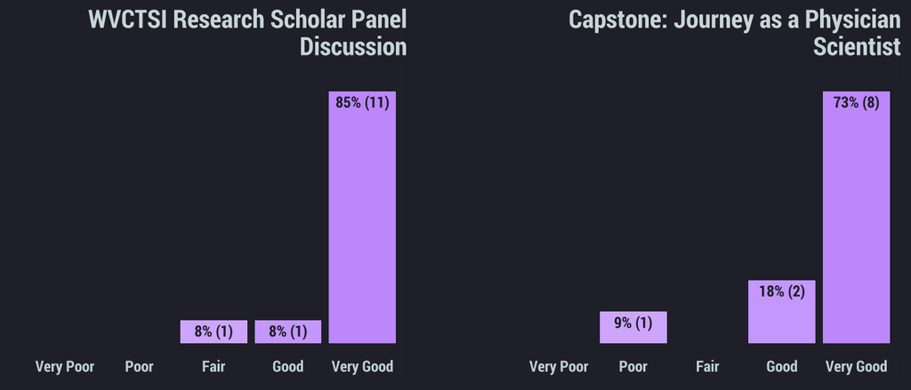

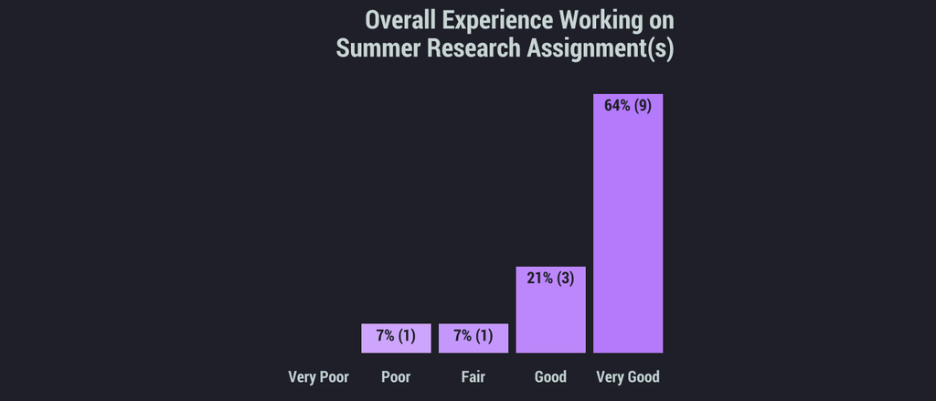

## Student Engagement

### Former Participants

A majority of participants indicated a desire to start or continue engagement with upcoming Summer Research Fellows

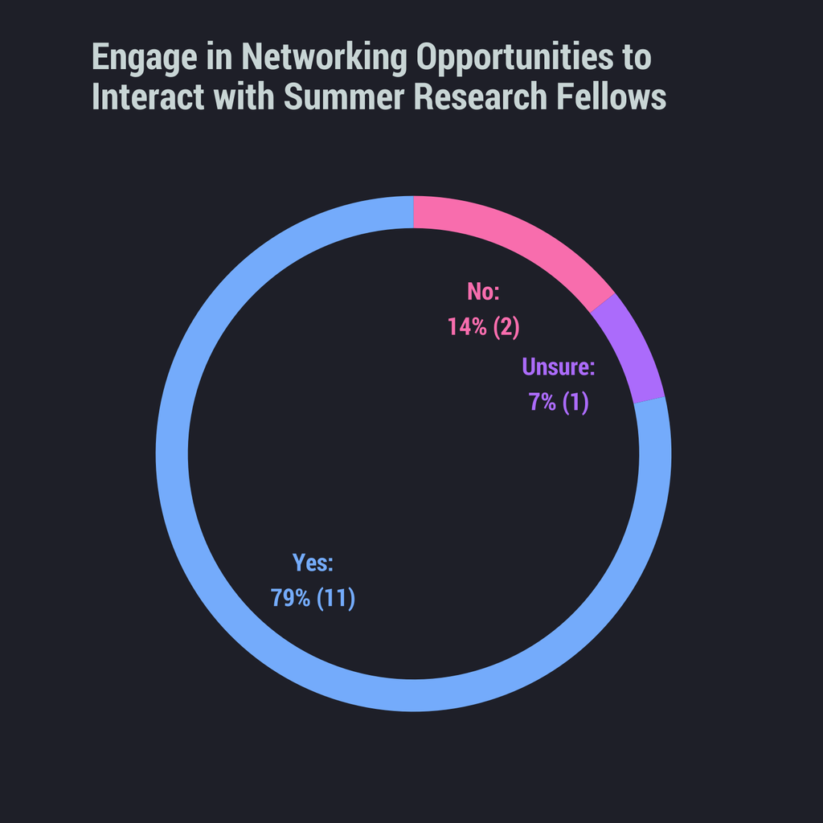

### Suggestions to Improve

Though a minority of former participants provided feedback describing actions that may be taken to keep an interest in research

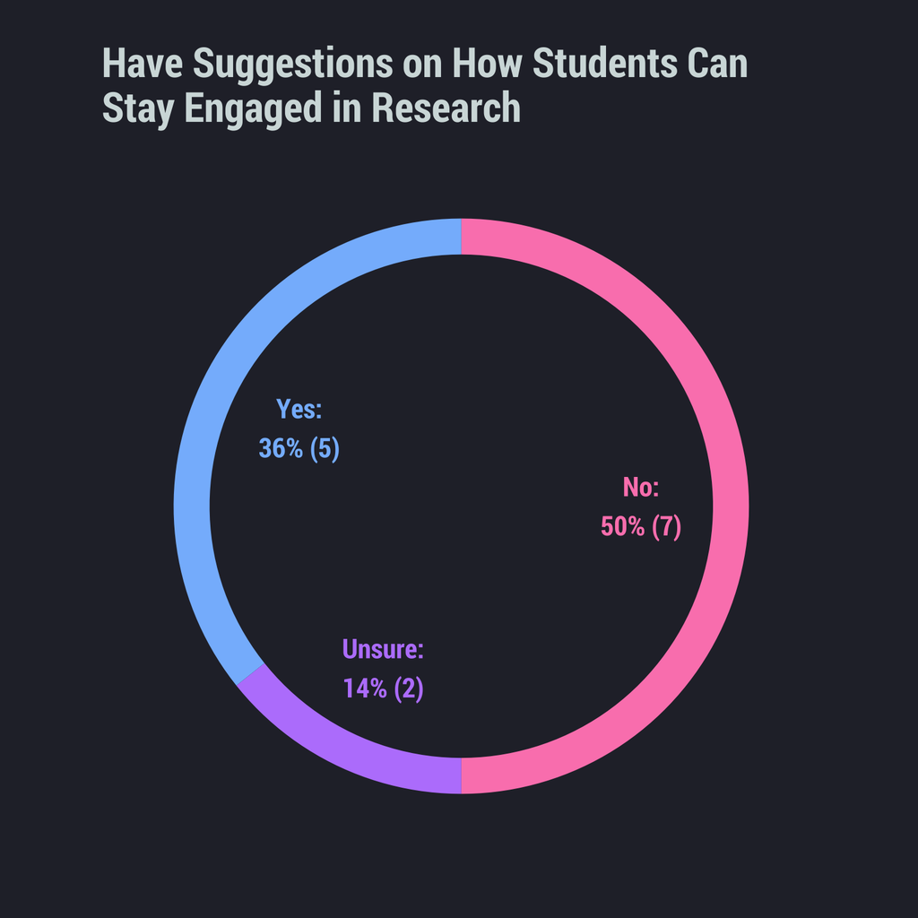

those who did respond noted the following advice should be shared with future incoming Fellows

> *I think it’s important to keep consistent contact with your PI, and make a to-do list to make sure you accomplish at least something each day.*

> *Be involved with research that you care about. If you are looking for answers to questions that mean something to you, it is a lot easier to be excited about your work.*

> *Being proactive and engaged in the research topics being studied is important, and making sure to read up on any papers suggested by the lab.*

> *Keep in contact with INTRO program’s PI throughout the year or just work on little project with them. Stay present through emails with them.*

> *After forming relationships with the researchers involved with the INTRO program, I think it is best for the student to take initiative to continue reaching out and staying in communication with them. The INTRO program allows for those relationships to be initially formed.*

> *I think the biggest thing is to continue to stretch your comfort zone and engage the research faculty at WVU. You’re now a graduate student and these individuals are too busy to target students for research opportunities. However, they are extremely friendly and can always use help on projects, so continue to reach out to PIs with who you are, why you think you could help in their projects, and asking them to be involved in their research.*

The following provides a broad overview of important pairs of terms that can be used to quickly understand the entire response set.

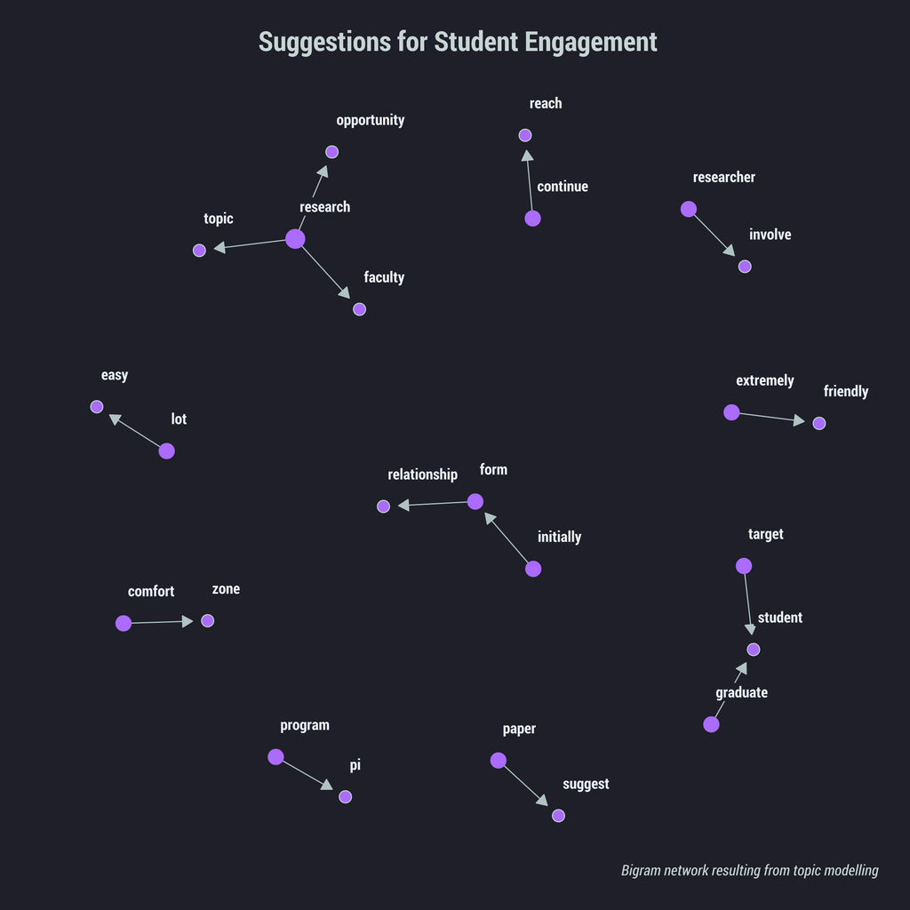

### Possible Career Goals

Without a prior assessment, it is unclear if the program had an impact on participant job aspirations. Regardless, a majority of respondents noted that they were unsure if a career in the clinical sciences would be appropriate choice.

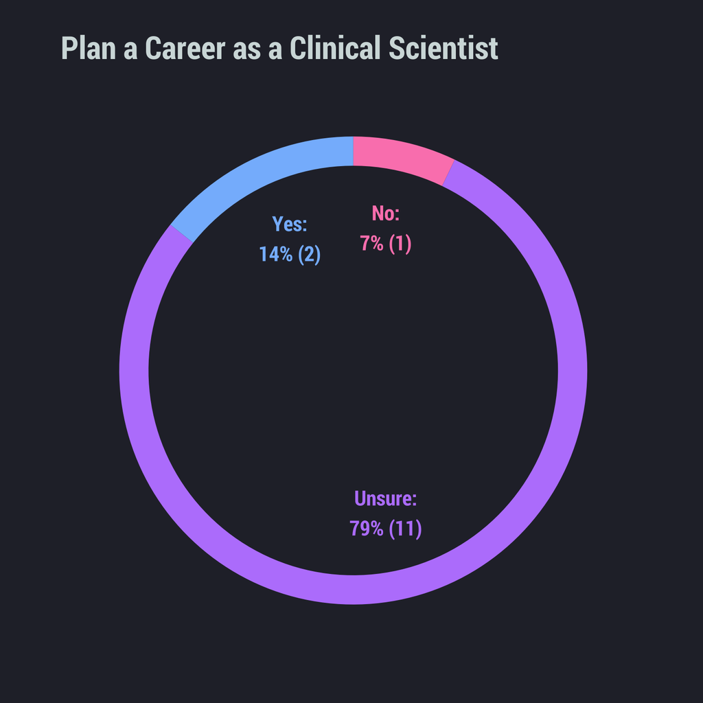

This uncertainty in future roles is likely supported by a low response rate (2) on those items assessing the impact of programmatic activities on a student’s career choices. Given that, both participants indicated they wished to pursue a career as a clinician scientist with both describing they were moderately to strongly influenced by

- Their research project
- Time in the laboratory
- The weekly seminars

## Favored Program Elements

Respondents conveyed a variety of aspects that were considered to be the best.

1. accommodation of dietary needs
2. connecting with mentors
3. creating relationships
4. enrichment sessions
5. networking
6. research opportunities
7. working in a team environment

The following provides a broad overview of important pairs of terms that can be used to quickly understand the entire response set.

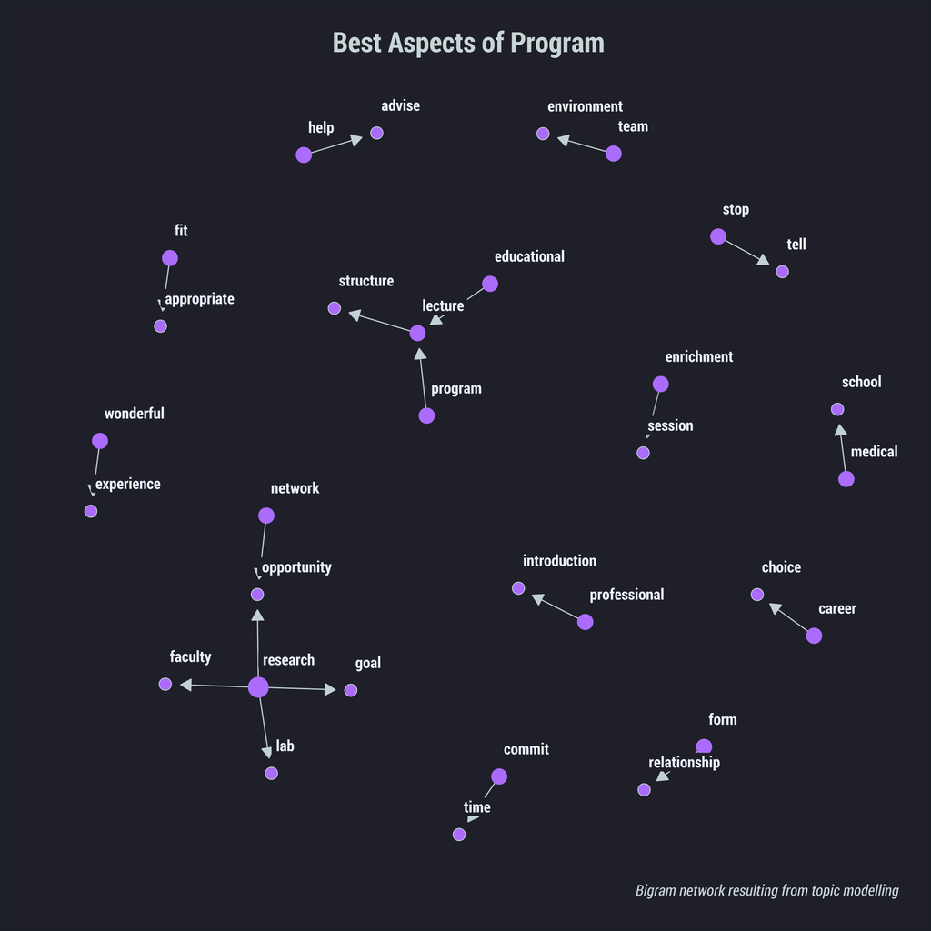

## Participant Satisfaction

Generally participants were mostly satisfied with the program. This is supported by the [Net Promoter Score](https://www.netpromoter.com/know/)® (NPS) profile derived from the overall response set. The NPS measures participant experience and predicts possible growth.

Respondents are grouped into the following classifications:

- *Promoters* (score 9-10) are loyal enthusiasts who are more likely to refer others to a program based on their experience.
- *Passives* (score 7-8) are satisfied but unenthusiastic former participants who are not certain about an experience.
- *Detractors* (score 0-6) are unhappy respondents who can damage a brand and impede growth through negative word-of-mouth.

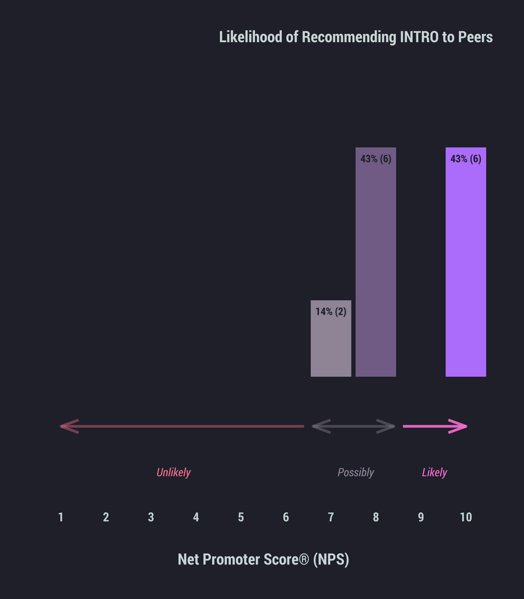

and notable responses such as

> *Thanks to Sarah and Jodie for organizing INTRO this past summer, I know it was difficult with COVID, but you did your best, and I think mostly everyone had a positive experience.*

> *This was a lovely and important experience for me. I do not think that very much needs to change about it.*

> *Thank you so much for allowing me to participate in the INTRO program this year. I really enjoyed my time and hope to continue to see it grow in the future.*

> *Thank you all for the opportunity to help me build my research skills and experiences. It was a very influential summer and I appreciate all the time you guys put into the summer to make our experiences enriching.*

> *This program was excellently run! It provided a much-needed introduction to research for me. Thanks for all you did to keep as much of it in-person as possible– this played a big part in my decision.*

Furthermore students generally maintained a positive view of their summer experience. The following provides a broad overview of important pairs of terms that can be used to quickly understand the entire response set.

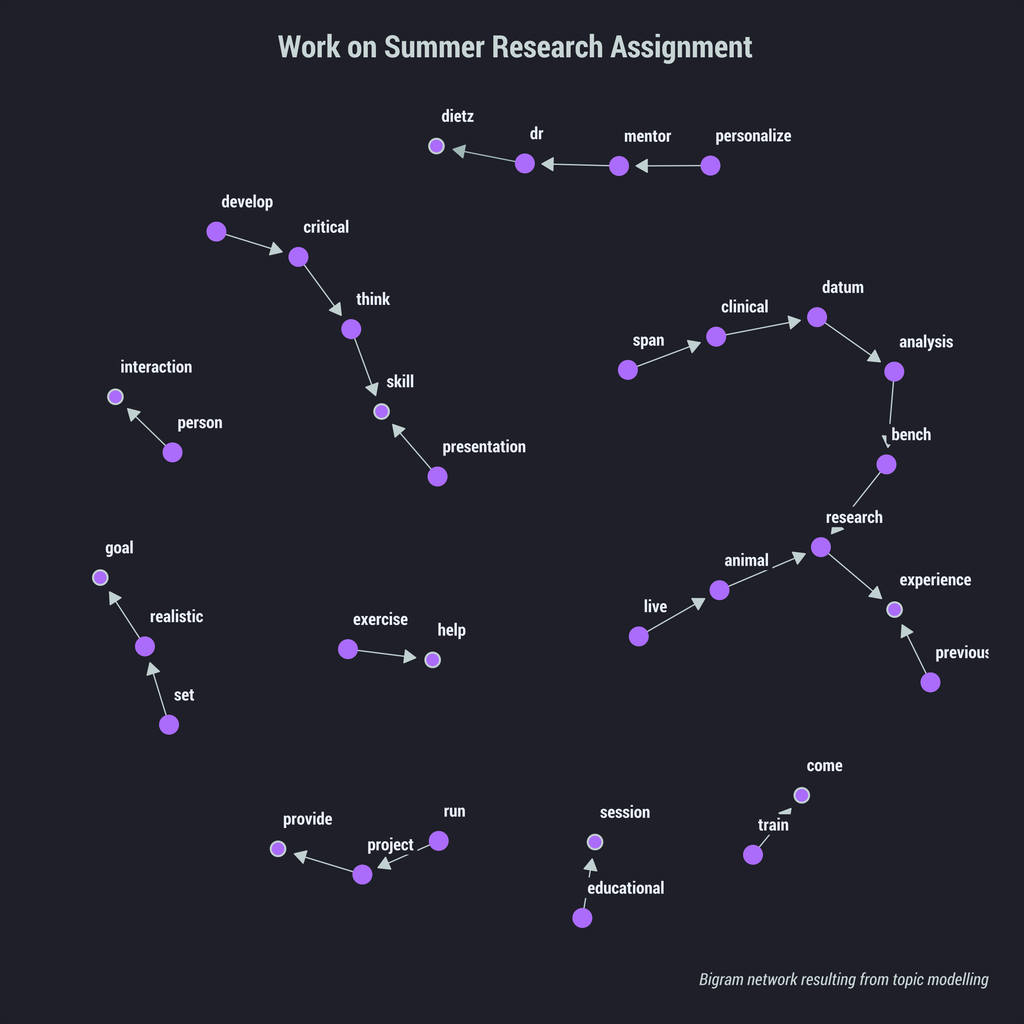

## Recommendations

### Given by Participants

The recommendations outlined by former students are provided as two sections - the first outlining aspects that would make the *program attractive to their peers* and second addressing *programmatic improvements*.

#### Attractiveness to Peers

- Availability of additional projects
- Increased attention given to advertising the program (e.g. showcasing INTRO students in email newsletters and social media)
- Greater clarity given in ways to interact with PIs
- Informational sessions provided earlier and with greater frequency
- Presentation administered at the end of the summer in lieu of spring
- Reaching out to more physicians and researchers to provide a wider variety of options as mentors
- Research fair where PIs would be able to present and discuss their research to students

#### Programmatic Improvements

- Additional opportunities for hands on experiences
- Clarity of expectations by a given mentor including a structured work timeline with realistic goals and checkpoints
- Continue providing parallel sessions on Zoom
- Further opportunities for hands on experiences
- Greater diversity in lunch options
- Increased availability of extracurricular opportunities
- More interactions with the WVU students
- Regular checkups for mentor-mentee pairs to assess progress
- Standardized interviews with PIs to ensure fit

### Suggested by the Evaluator

The following are overall program level recommendations derived from direct quotes and additional analyses conduced through the current evaluation.

- Apply additional resources to stress the benefits and possibilities of a career in the clinical sciences
- Consider administering a pre survey to assess if the program is impacting students in accordance to the program goals
- Continue to expand the footprint of the program by investing in advertising to a boarder audience or to the current population using a multimodal approach
- Identify additional ways that PIs can both communicate and expand on their research to current and future Fellows

  All analyses, visuals and markdown files were originally created by [Dr. Abhik Roy](https://iam.asocialdatascientist.com/) using [R](https://www.r-project.org/) and [R Studio](https://www.rstudio.com/) and are available upon request. Data sets are under the ownership of the WVCTSI. This work is the result of a joint partnership between the INTRO program and PERC and licensed under a [Creative Commons Attribution-NonCommercial-ShareAlike 4.0 International License](http://creativecommons.org/licenses/by-nc-sa/4.0/).

[figure not shown]